# Lecture #2: Review: Riemann Sums, Definite Integrals & the Fundamental Theorem of Calculus

MATH 146 – Calculus II

Torin Quinlivan

tquinlivan@knox.edu

Knox College

December 1, 2025

## Riemann Sums

Consider a function $f(x)$ defined on an interval $a \le t \le b$, and, given a whole number $n$, divide the interval into $n$ subintervals of length $\Delta t = \frac{(b-a)}{n}$ with endpoints $t_0, t_1, t_2, \dots, , t_n$.

The left (regular) Riemann sum is:

$$f(t_0) \Delta t + f(t_1) \Delta t + \dots + f(t_{n-1}) \Delta t = \sum_{i=0}^{n-1} f(t_i) \Delta t.$$

## Riemann Sums

Consider a function $f(x)$ defined on an interval $a \le t \le b$, and, given a whole number $n$, divide the interval into $n$ subintervals of length $\Delta t = \frac{(b-a)}{n}$ with endpoints $t_0, t_1, t_2, \dots, , t_n$.

The right (regular) Riemann sum is:

$$f(t_1) \Delta t + f(t_2) \Delta t + \dots + f(t_n) \Delta t = \sum_{i=1}^{n} f(t_i) \Delta t.$$

## Definite Integral

Given a continuous function $f(x)$ on an interval $a \le t \le b$, the definite integral of $f(x)$ over $[a,b]$ is the limit:

$$\begin{aligned}
\int_a^b f(t)\,dt &= \lim\limits_{n \to \infty} \sum_{i=1}^{n} f(t_i) \Delta t, & &\text{or} \\
\int_a^b f(t)\,dt &= \lim\limits_{n \to \infty} \sum_{i=0}^{n-1} f(t_i) \Delta t
\end{aligned}$$

provided these limits exist. $f(x)$ is called the integrand and $a$ and $b$ are called the limits of integration.

## Example: Definite Integral

**Example:** Consider the function $f(x) = x^2 + 1$ over the interval $[0, 2]$. For a given $n$, $\Delta t = \frac{2}{n}$ and $t_i = \frac{2i}{n}$, so that:

$$\int_0^2 x^2 + 1 \, dx = \lim\limits_{n \to \infty} ((\frac{2i}{n})^2 + 1) \times (\frac{2}{n}).$$

This sum can be thought of as a sum of areas of rectangles the graph of $f(x)$.

## Example: $n=5$

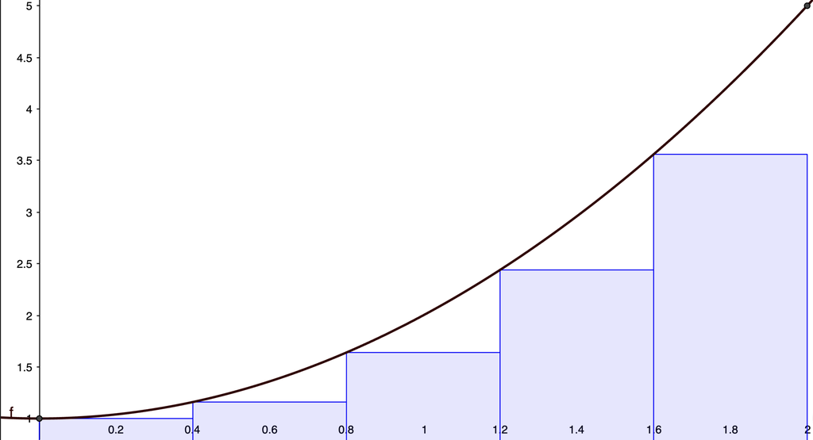

## Example: $n=10$

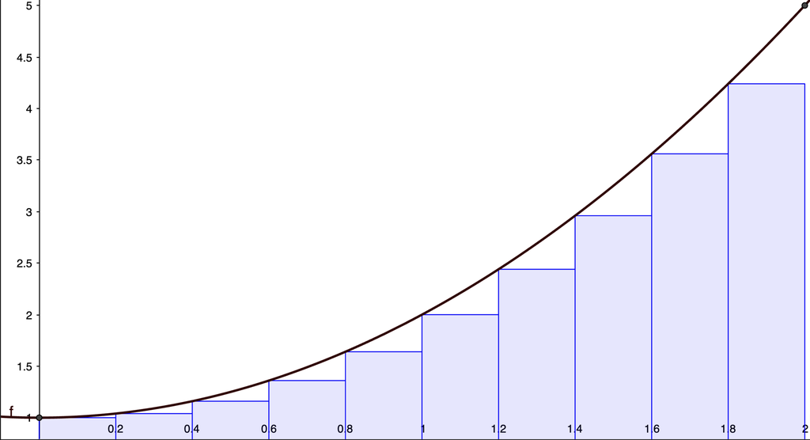

## Example: $n=20$

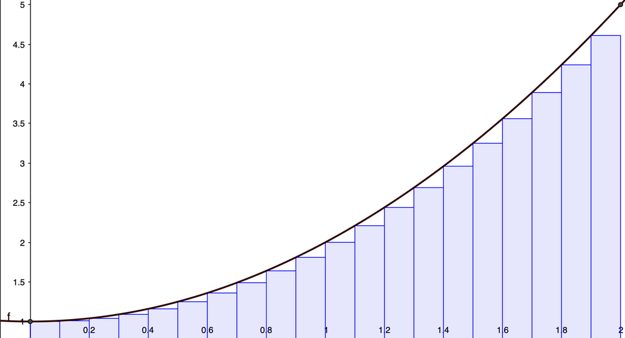

## Example: $n=50$

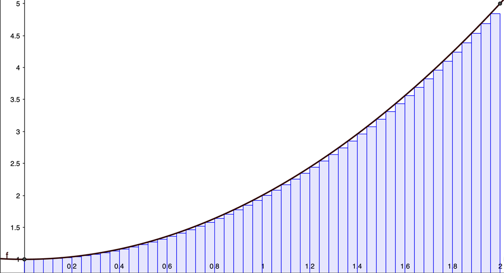

## Example: $n=100$

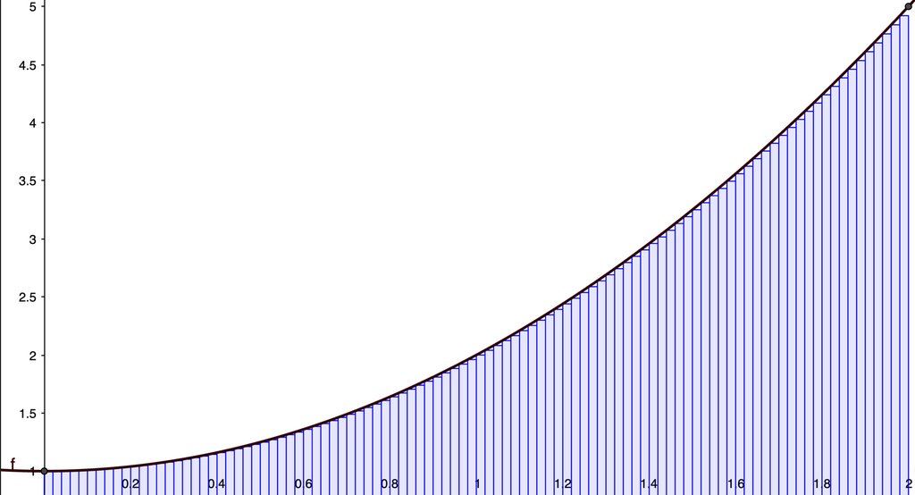

## Example: $n=1000$

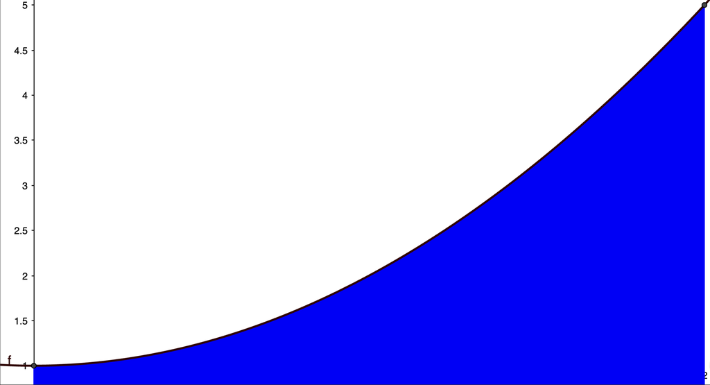

## Example: $n \to \infty$

As $n \to \infty$, this sum becomes the **area under the graph** of $f(x)$ over $[a,b]$.

$$\int_0^2 x^2 + 1 \, dx = \lim\limits_{i \to \infty} \sum_{i=0}^{n-1} ((\frac{2i}{n})^2 + 1) \times (\frac{2}{n}) = \frac{14}{3}$$

## The Definite Integral

Estimates of $\displaystyle\int_a^b f(x)\,dx$ can be obtained with left sums, right sums, sums from midpoint values of $f(x)$ or more general types of sums.

In simple cases, the values of $\displaystyle\int_a^b f(x)\,dx$ can be found simply by finding an area under a graph.

## Example: Definite Integral

**Example:** Evaluate $\displaystyle\int_0^2 -2x + 1\,dx$.

$\displaystyle\int_a^b f(x)\,dx$ is the **signed area** – that is, the area between the graph of $f(x)$ and the $x$-axis.

## Velocity and Distance

Recall the definition of rate of change: $r = \dfrac{d}{t}$. This implies that $d = rt$. Suppose $v(t)$ is the velocity of an object of an object at time $t$ and consider the distance traveled over the time interval $\Delta t$.

$$\begin{aligned}
\int_a^b v(t) \, dt &= \lim\limits_{n \to \infty} \sum_{i = 1}^n v(t_i) \Delta t \\
&= \textrm{distance traveled (displacement)} \\
&= \textrm{area under the graph of } v(t)
\end{aligned}$$

## Example: Velocity and Distance

The velocity of an object moving along an axis is described by the picture below. Find the displacement of the object from time $t=0$ to time $t=4$.

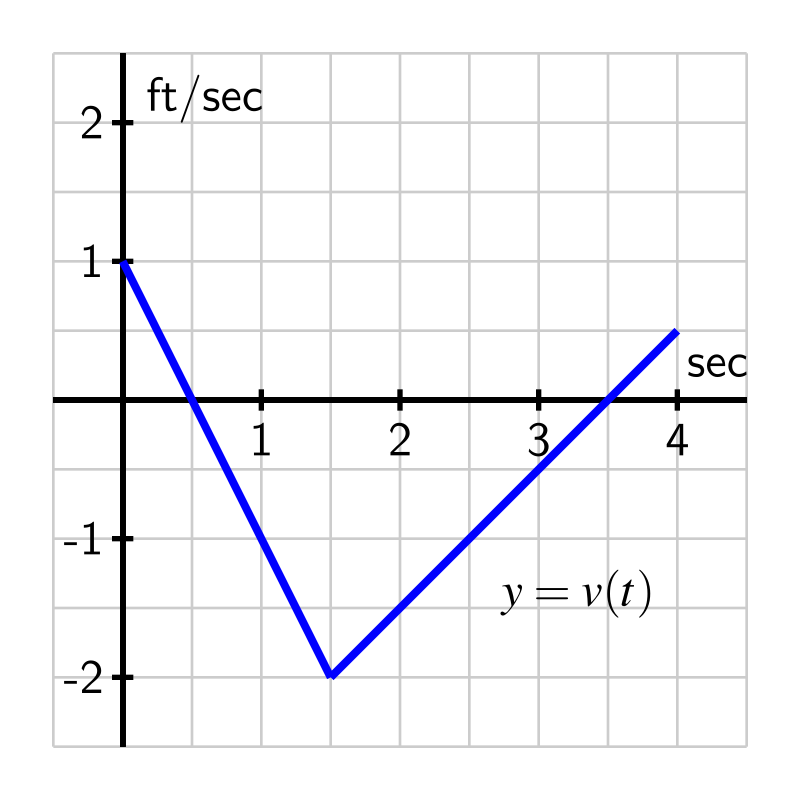

## The Fundamental Theorem of Calculus

Suppose $f(t)$ is a continuous function on the interval $[a, b]$ and that $F(t)$ is an antiderivative of $f(t)$. Then

$$\int_a^b f(t) \, dt = F(b) - F(a)$$

## The Fundamental Theorem of Calculus

**Notes:**

- This makes evaluating definite integrals easy, *provided you can find an antiderivative*.
- Alternatively, $\displaystyle\int_a^b f'(t) \, dt = f(b) - f(a)$.
- Also, $F(b) = F(a) + \displaystyle\int_a^b f(t) \, dt$.

## Example: The Fundamental Theorem of Calculus

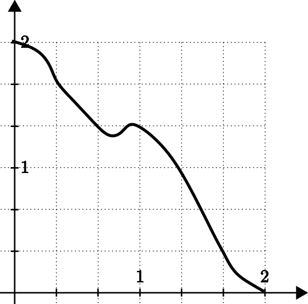

Estimate the amount of water in the tank at noon.

## Example: The Fundamental Theorem of Calculus

**Examples:**

1. Find $\displaystyle\int_0^2 3x+1 \, dx$.
2. Find $\displaystyle\int_1^3 (x-1)^2 \, dx$.

## Example: The Fundamental Theorem of Calculus

**Examples:**

3. Find $\displaystyle\int_0^{\frac{\pi}{2}} \sin(x) \, dx$.
4. Find $\displaystyle\int_0^3 e^x \, dx$.
5. Find $\displaystyle\int_0^{\pi} \cos(x) + \dfrac{1}{\sqrt{1 - x^2}} \, dx$.

## Some Theorems for Definite Integrals

- $\displaystyle\int_a^b c \cdot f(x) + d \cdot g(x) \, dx = c \displaystyle\int_a^b f(x) \, dx + d \displaystyle\int_a^b g(x) \, dx$.
- If $a < c < b$, $\displaystyle\int_a^b f(x) \, dx = \displaystyle\int_a^c f(x) \, dx + \displaystyle\int_c^b f(x) \, dx$.

**Note:** There is no product or quotient rule for definite integrals.

## The Fundamental Theorem of Calculus

Every continuous function $f(x)$ has an antiderivative. If $f(x)$ is a continuous function on an interval and $a$ is any point, then the function:

$$F(x) = \int_a^x f(t) \, dt,$$

is an antiderivative of $f(x)$. In other words:

$$\frac{d}{dx} \left[ \int_a^x f(t) \, dt \right] = f(x).$$